# TP5 - Visualisation sous `Python`

#### Analyse de Données Massives - Master 1ère année

Dans ce TP, nous allons utiliser le package [`seaborn`](https://seaborn.pydata.org), ainsi que le jeu de données `tips`, vu dans le TP précédent

```python
import numpy
import pandas
tips = pandas.read_csv("tips.csv", header = 0, sep = ",")
tips.head()
```

|  | total_bill | tip | sex | smoker | day | time | size |
| --- | --- | --- | --- | --- | --- | --- | --- |
| 0 | 16.99 | 1.01 | Female | No | Sun | Dinner | 2 |
| 1 | 10.34 | 1.66 | Male | No | Sun | Dinner | 3 |
| 2 | 21.01 | 3.50 | Male | No | Sun | Dinner | 3 |
| 3 | 23.68 | 3.31 | Male | No | Sun | Dinner | 2 |
| 4 | 24.59 | 3.61 | Female | No | Sun | Dinner | 4 |

## `seaborn`

Ce module, importé ci-dessous, est basé sur `matplotlib`. Il faut donc ajouter la ligne `%matplotlib inline` dans un *notebook*, pour pouvoir voir les graphiques.

Ce module contient toutes les fonctions directement, l'importation est donc assez simple.

```python
import seaborn

%matplotlib inline
```

### Variable quantitative

La fonction `distplot()` nous permet de réaliser les graphiques de distribution d'une variable quantitative. Par défaut, elle réaliser un histogramme avec une estimation de la densité.

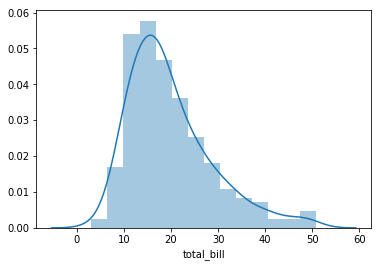

```python
seaborn.distplot(tips.total_bill)
```

Pour ne garder que l'histogramme, on indique qu'on ne souhaite pas l'estimation de la densité (paramètre `kde`). Ainsi, l'histogramme devient en effectifs.

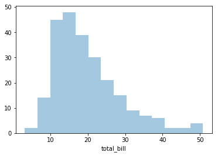

```python
seaborn.distplot(tips.total_bill, kde = False)
```

De même, on ne peut vouloir que la densité. Auquel cas, on supprimer l'histogramme avec le paramètre `hist`.

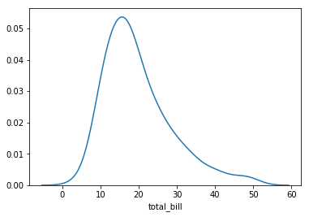

```python
seaborn.distplot(tips.total_bill, hist = False)
```

Il est possible de choisir le nombre de bins, avec le paramètre `bins`.

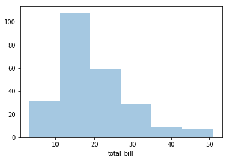

```python
seaborn.distplot(tips.total_bill, bins = 6, kde = False)
```

Il est aussi possible de choisir les limites des intervalles, avec le même paramètre `bins`. Dans ce cas, il faut bien évidemment veiller à faire un histogramme en densité. Si on ne souhaite pas avoir l'estimation de la densité, on peut l'obtenir tout de même avec le paramètre `norm_hist`.

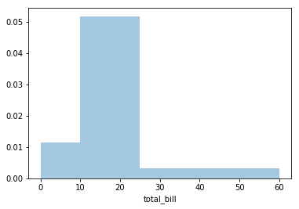

```python
seaborn.distplot(tips.total_bill, bins = [0, 10, 25, 60], norm_hist = True, kde = False)
```

C'est la fonction `boxplot()` qui nous permet de réaliser une boîte à moustache (soit verticale en mettant la variable en `y`, soit horizontale en la mettant en `x`).

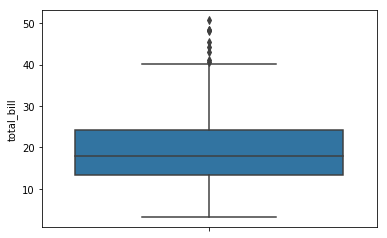

```python
seaborn.boxplot(y = "total_bill", data = tips)
```

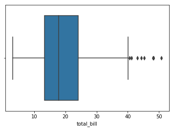

```python
seaborn.boxplot(x = "total_bill", data=tips)
```

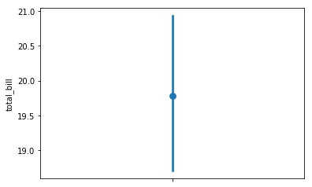

```python
seaborn.pointplot(y = "total_bill", data = tips)
```

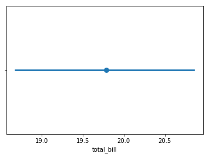

```python
seaborn.pointplot(x = "total_bill", data = tips)
```

Un autre graphique possible est celui obtenu avec `violinplot()`, qui représente la densité d'une variable, toujours avec le choix vertical/horizontale (`y`/`x`).

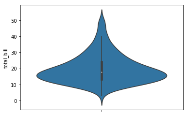

```python
seaborn.violinplot(y = "total_bill", data = tips)
```

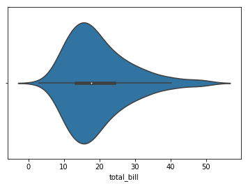

```python
seaborn.violinplot(x = "total_bill", data = tips)
```

Enfin, il est possible de représenter toutes les valeurs sur un *pseudo* nuage de points. Avec `striplot()` dont l'option `jitter` a été activée, les points sont aléatoirement répartis sur l'axe des $x$ (si on utilise `y` - inversement sinon).

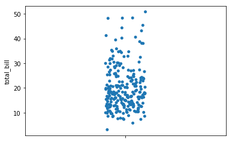

```python
seaborn.stripplot(y = "total_bill", data = tips, jitter = True)
```

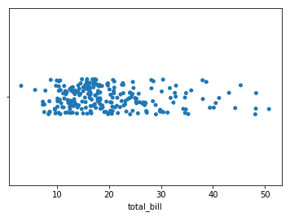

```python
seaborn.stripplot(x = "total_bill", data = tips, jitter = True)
```

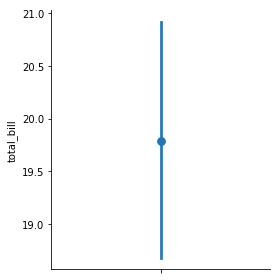

```python
seaborn.factorplot(y = "total_bill", data = tips, kind = "point")
```

### Variable qualitative

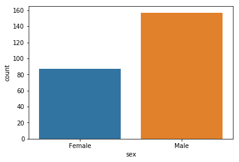

```python
seaborn.countplot(x = "sex", data = tips)
```

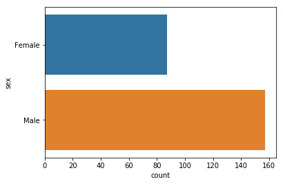

```python
seaborn.countplot(y = "sex", data = tips)
```

Pour avoir la version en pourcentages (ou en proportions) de ce graphique, nous devons utiliser la fonction `barplot()`, sur la table de proportions calculée avant. Cette fonction réalise un calcul (moyenne par défaut) sur une variable (ici `freq`) en fonction des modalités d'une autre variable (`sex` ici donc).

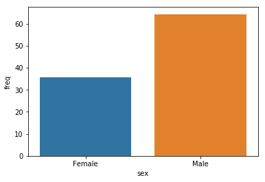

```python
t = pandas.crosstab(tips.sex, "freq", normalize=True)
t = t.assign(sex = t.index, freq = 100 * t.freq)
seaborn.barplot(x = "sex", y = "freq", data = t)
```

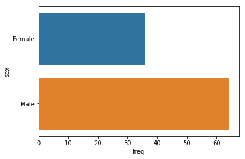

```python
seaborn.barplot(x = "freq", y = "sex", data = t)
```

Pour réaliser un diagramme en barres empilées, il faudra le créer soi-même. Nous ne verrons pas ici.

Enfin, comme précédemment, la fonction `factorplot()` nous permet d'accéder aux sous-fonctions avec le choix dans `kind`.

- `count` : diagramme en barres (dénombrement)
- `bar` : diagramme en barres avec calcul

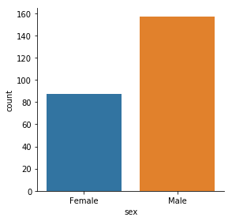

```python
seaborn.factorplot(x = "sex", data = tips, kind = "count")
```

### Var quantitative - Var quantitative

Pour réaliser le nuage de points, on utilise la fonction `jointplot()`. Elle a l'avantage d'ajouter par défaut les histogrammes de chaque variable. Elle réalise par défaut le nuage de points simple (`scatter`). Comme pour `factorplot()`, on va pouvoir choisir le type de graphique avec le paramètre `kind`.

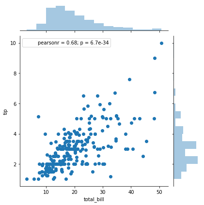

```python
seaborn.jointplot(x = "total_bill", y = "tip", data = tips)
```

En choississant le type `reg`, on obtient en plus l'ajustement linéaire de la variable en `y` par celle en `x`.

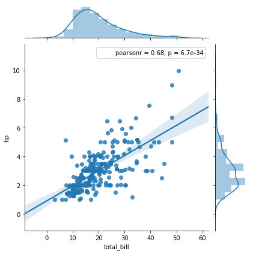

```python
seaborn.jointplot(x = "total_bill", y = "tip", data = tips, kind = "reg")
```

On peut obtenir une *heatmap*, non pas avec des rectangles mais un pavage hexagonal, avec `kind = "hex"`.

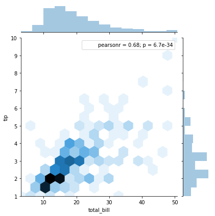

```python
seaborn.jointplot(x = "total_bill", y = "tip", data = tips, kind = "hex")
```

Enfin, on peut avoir une estimation de la densité en 2d avec le type `kde`.

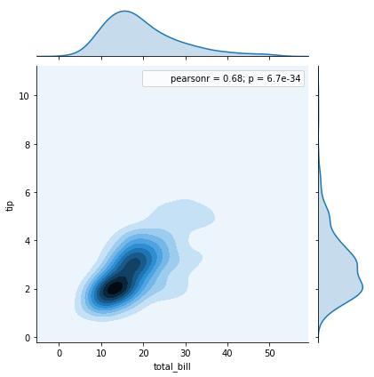

```python
seaborn.jointplot(x = "total_bill", y = "tip", data = tips, kind = "kde")
```

Si on souhaite ne pas avoir les distributions marginales, la fonction `regplot()` nous permet de réaliser le nuage de points avec ou sans ajustement (paramètre `fit_reg`). On peut aussi n'afficher que l'ajustement.

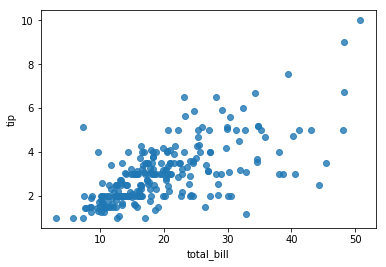

```python
seaborn.regplot("total_bill", "tip", data = tips, fit_reg = False)
```

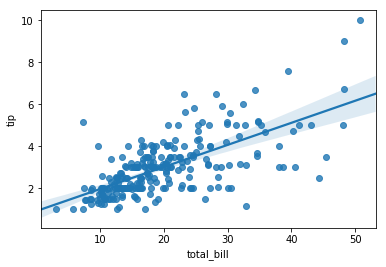

```python
seaborn.regplot("total_bill", "tip", data = tips)
```

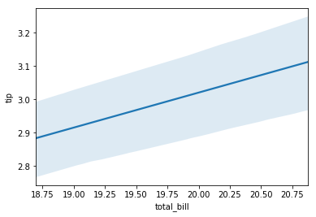

```python
seaborn.regplot("total_bill", "tip", data = tips, scatter = False)
```

Il est possible d'obtenir directement tous les nuages de points 2 à 2, avec la fonction `pairplot()`. Le paramètre `vars` permet de sélectionner certaines variables. Par défaut, la fonction utilise toutes les variables numériques.

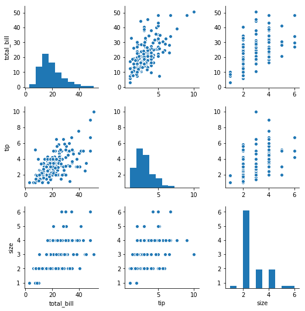

```python
seaborn.pairplot(data = tips, vars = ["total_bill", "tip", "size"])
```